# DEAP_n_queens_on_canvas

## Project 4: Solving N-Queens Problem using Genetic Algorithms

#### CSC 180 Intelligent Systems

#### Dr. Haiquan Chen, California State University, Sacramento

```python
# Insert your name, your id, course title, assignment id, and due date here as comment
#Steven Lum
#218975615
#CSC 180 - Intelligent Systems
#11/18/21
```

## Part I: Position-index-based board representation

```python
import random
import numpy as np
from deap import algorithms, base, creator, tools

creator.create("FitnessMin", base.Fitness, weights=(-1.0,))
creator.create("Individual", list, fitness=creator.FitnessMin)
```

```python
def create_individual():
    return random.sample(range(64), 8)
```

```python
print(create_individual())
```

```
[24, 18, 1, 17, 16, 6, 2, 8]
```

```python
def show_grid(board):

    n = [0]*64
    for i in board:
        n[i] = 1


    for i in range(8):
        for j in range(64):
            if j // 8 == i:
                if n[j] == 1:
                    print('X',end="|")
                else:
                    print('-',end="|")
        print()
        print("----------------")
```

```python
toolbox = base.Toolbox()

toolbox.register("individual", tools.initIterate, creator.Individual, create_individual)

toolbox.register("population", tools.initRepeat, list, toolbox.individual)
```

```python
pop = toolbox.population(n=5)

print(pop[0])
```

```
[37, 52, 46, 6, 42, 26, 7, 47]
```

```python
show_grid(pop[0])
```

```
-|-|-|-|-|-|X|X|
----------------
-|-|-|-|-|-|-|-|
----------------
-|-|-|-|-|-|-|-|
----------------
-|-|X|-|-|-|-|-|
----------------
-|-|-|-|-|X|-|-|
----------------
-|-|X|-|-|-|X|X|
----------------
-|-|-|-|X|-|-|-|
----------------
-|-|-|-|-|-|-|-|
----------------
```

### 10 pts: Write your code in the cell below to define the "evaFitness" function, which returns the fitness of any given board.

- Noticed that in this case, mutation may generate invalid board, e.g., the board with dupliciate positions. Think about [5, 32, 8, 8, 41, 3, 55, 49]
- How to exclude those invalid boards from each generation? One way is to add some penalty to the fitness value of invalid boards. In that case, any invalid board will have a very high fitness value (remember that our goal is to find the board with least fitness value). To do that, let's write a function *checkDuplicate()* to calculate the number of queen pairs in the same position for any given board. *Give each duplicate a high penalty (i.e., multiply by 20, 50) and add the penalty to the fitness value.*
- evaFitness() returns the total number of duplicate position pair (with penalty) plus the total number of distinct pairs of queens that attack each other.

```python
#fitness function
def evaFitness(individual):

    conflict = 0

    for piece in range(len(individual)):
        conflictingValues = list()
        startPosition = individual[piece]
        piecePosition = startPosition
        rowStart = int(individual[piece]/8)*8
        rowEnd = int(individual[piece]/8) * 8 + 8
        #rows
        for i in range(rowStart, rowEnd):
            conflictingValues.append(i)
        #columns
        while(piecePosition > 7):
            piecePosition = piecePosition - 8
            conflictingValues.append(piecePosition)
        piecePosition = startPosition
        while(piecePosition < 56):
            piecePosition = piecePosition + 8
            conflictingValues.append(piecePosition)
        #diagonals
        #upper left
        piecePosition = startPosition
        x,y = startPosition-rowStart, int(startPosition/8)
        while( x > 0 and y > 0):
            piecePosition = piecePosition - 9
            conflictingValues.append(piecePosition)
            x = x - 1
            y = y - 1
        #upper Right
        piecePosition = startPosition
        x,y = 8-(startPosition-rowStart)-1, int(startPosition/8)
        while( x > 0 and y > 0):
            piecePosition = piecePosition - 7
            conflictingValues.append(piecePosition)
            x = x - 1
            y = y - 1
        #bottom Left
        piecePosition = startPosition
        x,y = startPosition-rowStart, 8-int(startPosition/8)-1
        while(x > 0 and y > 0):
            piecePosition = piecePosition + 7
            conflictingValues.append(piecePosition)
            x = x - 1
            y = y - 1
        #bottomRight
        piecePosition = startPosition
        x,y = 8-(startPosition-rowStart)-1, 8-int(startPosition/8)-1
        while(x > 0 and y > 0):
            piecePosition = piecePosition + 9
            conflictingValues.append(piecePosition)
            x = x - 1
            y = y - 1


        conflictingValues.remove(startPosition)
        conflictedWith = list()

        for otherPieces in individual:
            if otherPieces in conflictingValues:
                conflict = conflict + 1
                conflictedWith.append(otherPieces)


        #print(startPosition)
        #print(conflictingValues)
        #print(conflictedWith)


    conflict = conflict / 2
    return (checkDuplicate(individual) + conflict,)


# Calculate the number of queen pairs in the same position for any given board
def checkDuplicate(individual):
    dup = 0
    for i in range(len(individual)):
        for j in range(len(individual)):
            if (i != j):
                if (individual[i] == individual[j]):
                    dup = dup + 1

    return dup*100 #50 is the penalty for duplicates
```

### 5 pts: Writer your code in the cell below to register "evaluate" function to toolbox

```python
toolbox.register("evaluate", evaFitness)
```

```python
toolbox.register("mate", tools.cxTwoPoint)

toolbox.register("mutate", tools.mutUniformInt, low = 0, up = 63, indpb=0.1)

toolbox.register("select", tools.selTournament, tournsize=3)
```

```python
stats = tools.Statistics(key=lambda ind: ind.fitness.values)
```

```python
stats.register("avg", np.mean)
stats.register("min", np.min)
```

### 10 pts: Writer your code in the cell below to create the first generation, the hall of fame, and launch the genetic algorithm: eaSimple(). How many individuals you want to have for each generation and how many generations you want GA to go thourgh for each run? Vary those two parameters to see the change.

```python
pop = toolbox.population(n=100)

hof = tools.HallOfFame(maxsize=1)

pop, log = algorithms.eaSimple(pop, toolbox, cxpb=0.5, mutpb=0.2, ngen=100,
                                   stats=stats, halloffame=hof, verbose=True)
```

```
gen	nevals	avg  	min
0  	100   	10.06	5
1  	61    	28.17	4
2  	54    	23.59	3
3  	56    	38.64	3
4  	55    	28.29	3
5  	56    	17.56	3
6  	51    	14.89	3
7  	71    	21.04	3
8  	71    	20.61	3
9  	65    	24.54	3
10 	58    	18.16	3
11 	75    	12.03	3
12 	66    	13.88	3
13 	65    	13.62	3
```

[output cut: 87 more lines]

### 5 pts: Plot the "avg" and "min" for each generation

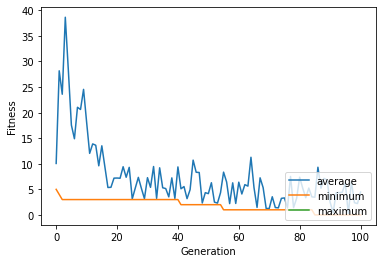

```python
import matplotlib.pyplot as plt
%matplotlib inline
gen, avg, min_, max_ = log.select("gen", "avg", "min", "max")

plt.plot(gen, avg, label="average")
plt.plot(gen, min_, label="minimum")
plt.plot(gen, max_, label="maximum")
plt.xlabel("Generation")
plt.ylabel("Fitness")
plt.legend(loc="lower right")
plt.show()
```

### 5 pts: Print out the best individual found and its fitness value. Show the best individual as chessboard

```python
print(hof[0])
print(hof[0].fitness)
show_grid(hof[0])
```

```
[34, 53, 24, 1, 47, 59, 12, 22]
(0.0,)
-|X|-|-|-|-|-|-|
----------------
-|-|-|-|X|-|-|-|
----------------
-|-|-|-|-|-|X|-|
----------------
X|-|-|-|-|-|-|-|
----------------
-|-|X|-|-|-|-|-|
----------------
-|-|-|-|-|-|-|X|
----------------
-|-|-|-|-|X|-|-|
----------------
-|-|-|X|-|-|-|-|
----------------
```

## Experimental

```python
pop = toolbox.population(n=200)

hof = tools.HallOfFame(maxsize=1)

pop, log = algorithms.eaSimple(pop, toolbox, cxpb=0.5, mutpb=0.2, ngen=1000,
                                   stats=stats, halloffame=hof, verbose=True)
```

```
gen	nevals	avg   	min
0  	200   	10.215	4
1  	131   	37.69 	4
2  	120   	30.63 	4
3  	120   	34.015	3
4  	130   	37.45 	3
5  	127   	27.445	4
6  	125   	29.995	3
7  	105   	21.475	2
8  	115   	28.5  	2
9  	115   	25.945	1
10 	102   	28.7  	1
11 	106   	19.65 	1
12 	119   	17.24 	1
13 	124   	31.16 	1
14 	113   	25.52 	1
15 	106   	24.235	1
16 	126   	25.1  	1
17 	109   	13.62 	1
18 	129   	5.135 	1
19 	112   	2.59  	1
20 	120   	4.445 	1
21 	116   	3.205 	1
22 	115   	5.4   	1
23 	115   	2.29  	1
24 	130   	2.36  	1
25 	104   	8.19  	1
26 	119   	4.38  	1
27 	123   	9.455 	1
28 	110   	5.345 	1
29 	114   	4.355 	1
30 	121   	4.29  	1
31 	129   	5.445 	1
32 	122   	4.405 	1
33 	111   	2.3   	1
34 	117   	5.325 	1
35 	113   	8.17  	1
36 	132   	3.2   	1
37 	129   	2.32  	1
38 	117   	7.255 	1
```

[output cut: 947 more lines]

```
986	110   	4.21  	1
987	125   	7.325 	1
988	114   	2.265 	1
989	124   	4.375 	1
990	115   	6.37  	1
991	108   	2.255 	1
992	129   	3.53  	1
993	117   	2.36  	1
994	115   	5.22  	1
995	116   	3.37  	1
996	119   	4.225 	1
997	113   	4.36  	1
998	103   	4.295 	1
999	118   	5.4   	1
1000	124   	5.36  	1
```

```python
pop = toolbox.population(n=200)

hof = tools.HallOfFame(maxsize=1)

pop, log = algorithms.eaSimple(pop, toolbox, cxpb=0.5, mutpb=0.2, ngen=1000,
                                   stats=stats, halloffame=hof, verbose=True)
```

```
gen	nevals	avg   	min
0  	200   	10.025	5
1  	122   	25.425	4
2  	116   	30.95 	4
3  	116   	19.33 	4
4  	116   	24.525	3
5  	120   	29.21 	3
6  	101   	17.64 	3
7  	132   	30.2  	3
8  	96    	15.985	3
9  	119   	26.59 	2
10 	113   	24.645	2
11 	109   	21.34 	2
12 	106   	22.055	2
13 	140   	19.2  	2
14 	117   	15.955	2
15 	119   	19.775	1
16 	130   	14.445	1
17 	113   	5.73  	1
18 	109   	4.59  	1
19 	109   	5.775 	1
20 	116   	5.5   	1
21 	127   	3.93  	0
22 	110   	5.19  	0
23 	113   	4.645 	0
24 	131   	6.295 	0
25 	140   	2.07  	0
26 	105   	1.74  	0
27 	114   	4.48  	0
28 	122   	7.37  	0
29 	130   	3.375 	0
30 	115   	5.3   	0
31 	122   	3.38  	0
32 	120   	1.35  	0
33 	134   	3.45  	0
34 	127   	5.37  	0
35 	120   	2.405 	0
36 	120   	2.285 	0
37 	123   	2.33  	0
38 	109   	3.345 	0
```

[output cut: 947 more lines]

```
986	133   	4.35  	0
987	138   	4.165 	0
988	135   	2.31  	0
989	122   	3.305 	0
990	135   	2.505 	0
991	110   	6.37  	0
992	132   	9.445 	0
993	125   	6.215 	0
994	115   	7.41  	0
995	117   	1.39  	0
996	108   	3.33  	0
997	122   	4.545 	0
998	129   	3.435 	0
999	111   	1.39  	0
1000	120   	2.22  	0
```

```python
pop = toolbox.population(n=200)

hof = tools.HallOfFame(maxsize=1)

pop, log = algorithms.eaSimple(pop, toolbox, cxpb=0.5, mutpb=0.2, ngen=100,
                                   stats=stats, halloffame=hof, verbose=True)
```

```
gen	nevals	avg   	min
0  	200   	10.435	4
1  	115   	30.82 	4
2  	117   	23.015	4
3  	133   	37.205	3
4  	137   	28.775	3
5  	123   	31.165	3
6  	128   	25.84 	3
7  	120   	30.295	3
8  	136   	34.94 	3
9  	121   	38.45 	3
10 	118   	23.1  	3
11 	124   	16.355	2
12 	115   	12.415	3
13 	128   	17.455	3
```

[output cut: 87 more lines]

```python
pop = toolbox.population(n=500)

hof = tools.HallOfFame(maxsize=1)

pop, log = algorithms.eaSimple(pop, toolbox, cxpb=0.5, mutpb=0.2, ngen=100,
                                   stats=stats, halloffame=hof, verbose=True)
```

```
gen	nevals	avg  	min
0  	500   	10.14	4
1  	307   	26.564	4
2  	270   	30.292	4
3  	292   	28.102	3
4  	287   	34.384	3
5  	297   	34.178	3
6  	263   	29.982	3
7  	302   	31.026	2
8  	312   	39.954	2
9  	305   	42.394	2
10 	265   	32.176	2
11 	309   	32.478	2
12 	304   	32.334	2
13 	292   	24.186	2
```

[output cut: 87 more lines]

## Part II: Row-index-based board representation

```python
import random
import numpy as np
from deap import algorithms, base, creator, tools

creator.create("FitnessMin", base.Fitness, weights=(-1.0,))
creator.create("Individual", list, fitness=creator.FitnessMin)
```

Each row of the chess row is indexed from 0->7 . we place different queens on different rows initially. The sequence [ a b c d .... ] means that in $0^{th}$ row, $a^{th}$ column, the queen is present and so on

```python
toolbox = base.Toolbox()

toolbox.register("attr_int", random.randint, 0, 7)
toolbox.register("individual", tools.initRepeat, creator.Individual,
                 toolbox.attr_int, n=8)
```

```python
toolbox.individual()
```

```
[1, 7, 2, 6, 7, 1, 6, 3]
```

```python
def show_grid(board):

    n = [0]*64

    for i in range(len(board)):
        n[board[i] + i*8] = 1


    for i in range(8):
        for j in range(64):
            if j // 8 == i:
                if n[j] == 1:
                    print('X',end="|")
                else:
                    print('-',end="|")
        print()
        print("----------------")
```

```python
toolbox.register("population", tools.initRepeat, list, toolbox.individual)
```

```python
pop = toolbox.population(n=5)

print(pop[0])
```

```
[1, 2, 7, 0, 1, 1, 7, 7]
```

```python
show_grid(pop[0])
```

```
-|X|-|-|-|-|-|-|
----------------
-|-|X|-|-|-|-|-|
----------------
-|-|-|-|-|-|-|X|
----------------
X|-|-|-|-|-|-|-|
----------------
-|X|-|-|-|-|-|-|
----------------
-|X|-|-|-|-|-|-|
----------------
-|-|-|-|-|-|-|X|
----------------
-|-|-|-|-|-|-|X|
----------------
```

### 10 pts: Write your code in the cell below to define the "evaFitness" function, which return the fitness of any given board

- evaFitness() returns the total number of distinct pairs of queens that attack each other.
- The following are some test cases you may use to verify the correctness of the evaFitness() function:
  - evaFitness([0, 2, 6, 7, 7, 4, 1, 6]) should return (4,)
  - evaFitness([7, 5, 2, 4, 3, 1, 3, 5]) should return (6,)
  - evaFitness([3, 1, 6, 0, 5, 7, 2, 1]) should return (5,)
  - evaFitness([7, 3, 1, 4, 5, 1, 3, 5]) should return (6,)

```python
#fitness function
def evaFitness(individual):

    conflict = 0
    # check if any individual is above or below the current piece
    #piece is being used as the y value
    for piece in range(len(individual)):
        for otherPiece in range(len(individual)):
            if piece != otherPiece:
                if individual[piece] == individual[otherPiece]:
                    conflict = conflict + 1

    #check upper left diagonals

    for piece in range(len(individual)):
        x,y = individual[piece],piece
        n,m = 0,0
        temp = 0
        #print(str(x) + " " + str(y))
        if y > 0:
            while n < x and m < y:
                n = n + 1
                m = m + 1
                temp = (individual[piece]+7*n)%8
                check = individual[piece-n]
                if temp == check:
                    conflict = conflict + 1
    #upper right
    for piece in range(len(individual)):
        x,y = 8-individual[piece]-1,piece
        n,m = 0,0
        temp = 0
        #print(str(x) + " " + str(y))
        if y > 0:
            while n < x and m < y:
                n = n + 1
                m = m + 1
                temp = (individual[piece]+9*n)%8
                check = individual[piece-n]
                if temp == check:
                    conflict = conflict + 1
    #lower left
    for piece in range(len(individual)):
        x,y = individual[piece],8-piece-1
        n,m = 0,0
        temp = 0
        #print(str(x) + " " + str(y))
        if y > 0:
            while n < x and m < y:
                n = n + 1
                m = m + 1
                temp = (individual[piece]+7*n)%8
                check = individual[piece+n]
                if temp == check:
                    conflict = conflict + 1
    #lower right
    for piece in range(len(individual)):
            x,y = 8-individual[piece]-1,8-piece-1
            n,m = 0,0
            temp = 0
            #print(str(x) + " " + str(y))
            if y > 0:
                while n < x and m < y:
                    n = n + 1
                    m = m + 1
                    temp = (individual[piece]+9*n)%8
                    check = individual[piece+n]
                    if temp == check:
                        conflict = conflict + 1

    conflict = conflict/2
    return (conflict,)
```

```python
evaFitness(pop[0])
```

```
(11.0,)
```

### 5 pts: Writer your code in the cell below to register "evaluate" function to toolbox

```python
toolbox.register("evaluate", evaFitness)
```

```python
toolbox.register("mate", tools.cxTwoPoint)

toolbox.register("mutate", tools.mutUniformInt, low = 0, up = 7, indpb=0.1)

toolbox.register("select", tools.selTournament, tournsize=3)
```

```python
stats = tools.Statistics(key=lambda ind: ind.fitness.values)


stats.register("avg", np.mean)
stats.register("min", np.min)
```

### 10 pts: Writer your code in the cell below to create the first generation, the hall of fame, and launch the genetic algorithm: eaSimple(). How many individuals you want to have for each generation and how many generations you want GA to go thourgh for each run? Vary those two parameters to see the change.

```python
pop = toolbox.population(n=100)

hof = tools.HallOfFame(maxsize=1)

pop, log = algorithms.eaSimple(pop, toolbox, cxpb=0.5, mutpb=0.2, ngen=100,
                                   stats=stats, halloffame=hof, verbose=True)
```

```
gen	nevals	avg 	min
0  	100   	7.85	3
1  	52    	6.58	3
2  	59    	5.78	3
3  	66    	5.54	2
4  	84    	5.32	2
5  	67    	4.54	2
6  	65    	3.74	2
7  	60    	3.1 	0
8  	64    	2.45	0
9  	63    	1.93	0
10 	71    	1.25	0
11 	59    	0.57	0
12 	57    	0.39	0
13 	58    	0.33	0
```

[output cut: 87 more lines]

### 5 pts: Plot the "avg" and "min" for each generation

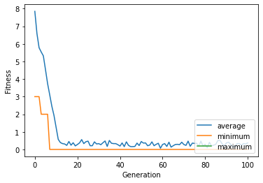

```python
# Plot the "avg" and "min" for each generation
import matplotlib.pyplot as plt
%matplotlib inline
gen, avg, min_, max_ = log.select("gen", "avg", "min", "max")

plt.plot(gen, avg, label="average")
plt.plot(gen, min_, label="minimum")
plt.plot(gen, max_, label="maximum")
plt.xlabel("Generation")
plt.ylabel("Fitness")
plt.legend(loc="lower right")
plt.show()
```

### 5 pts: Print out the best individual found and its fitness value. Show the best individual as chessboard

```python
print(hof[0])
print(hof[0].fitness)
show_grid(hof[0])
```

```
[4, 6, 1, 5, 2, 0, 7, 3]
(0.0,)
-|-|-|-|X|-|-|-|
----------------
-|-|-|-|-|-|X|-|
----------------
-|X|-|-|-|-|-|-|
----------------
-|-|-|-|-|X|-|-|
----------------
-|-|X|-|-|-|-|-|
----------------
X|-|-|-|-|-|-|-|
----------------
-|-|-|-|-|-|-|X|
----------------
-|-|-|X|-|-|-|-|
----------------
```

## Experimental

```python
pop = toolbox.population(n=200)

hof = tools.HallOfFame(maxsize=1)

pop, log = algorithms.eaSimple(pop, toolbox, cxpb=0.5, mutpb=0.2, ngen=1000,
                                   stats=stats, halloffame=hof, verbose=True)
```

```
gen	nevals	avg 	min
0  	200   	7.95	3
1  	121   	6.39	3
2  	105   	5.605	2
3  	110   	4.915	1
4  	123   	4.525	1
5  	125   	4.265	1
6  	131   	4.375	2
7  	125   	3.955	2
8  	115   	3.69 	2
9  	120   	3.495	1
10 	109   	3.295	1
11 	98    	2.905	1
12 	131   	3.18 	1
13 	120   	2.88 	1
14 	118   	3.14 	1
15 	125   	2.76 	1
16 	106   	2.445	1
17 	120   	2.205	1
18 	123   	2.035	1
19 	114   	1.7  	1
20 	121   	1.545	1
21 	115   	1.49 	1
22 	112   	1.445	1
23 	117   	1.41 	1
24 	110   	1.205	1
25 	114   	1.29 	1
26 	119   	1.37 	1
27 	132   	1.385	1
28 	113   	1.225	1
29 	117   	1.235	1
30 	109   	1.185	1
31 	123   	1.405	1
32 	136   	1.21 	1
33 	128   	1.275	1
34 	124   	1.29 	1
35 	119   	1.29 	1
36 	106   	1.21 	1
37 	98    	1.18 	1
38 	113   	1.22 	1
```

[output cut: 947 more lines]

```
986	126   	0.255	0
987	121   	0.28 	0
988	120   	0.21 	0
989	111   	0.205	0
990	109   	0.29 	0
991	127   	0.25 	0
992	137   	0.38 	0
993	129   	0.285	0
994	115   	0.36 	0
995	111   	0.33 	0
996	126   	0.35 	0
997	109   	0.33 	0
998	111   	0.285	0
999	125   	0.29 	0
1000	117   	0.305	0
```

```python
pop = toolbox.population(n=100)

hof = tools.HallOfFame(maxsize=1)

pop, log = algorithms.eaSimple(pop, toolbox, cxpb=0.5, mutpb=0.2, ngen=1000,
                                   stats=stats, halloffame=hof, verbose=True)
```

```
gen	nevals	avg	min
0  	100   	7.9	4
1  	55    	6.31	2
2  	62    	5.48	2
3  	60    	5.02	2
4  	56    	4.59	2
5  	56    	4.15	2
6  	58    	3.62	2
7  	60    	3.6 	2
8  	63    	3.33	2
9  	59    	2.74	2
10 	67    	2.63	2
11 	54    	2.35	2
12 	66    	2.4 	2
13 	67    	2.47	1
14 	68    	2.47	1
15 	61    	2.02	1
16 	65    	1.66	1
17 	58    	1.42	1
18 	64    	1.23	1
19 	65    	1.28	1
20 	61    	1.3 	1
21 	53    	1.29	1
22 	65    	1.18	1
23 	59    	1.11	0
24 	64    	1.33	0
25 	61    	1.13	0
26 	57    	1.09	0
27 	59    	0.72	0
28 	64    	0.4 	0
29 	56    	0.41	0
30 	57    	0.51	0
31 	68    	0.39	0
32 	67    	0.37	0
33 	58    	0.28	0
34 	50    	0.22	0
35 	63    	0.42	0
36 	58    	0.27	0
37 	63    	0.3 	0
38 	63    	0.23	0
```

[output cut: 947 more lines]

```
986	63    	0.17	0
987	52    	0.28	0
988	54    	0.18	0
989	70    	0.24	0
990	60    	0.3 	0
991	59    	0.44	0
992	47    	0.22	0
993	63    	0.4 	0
994	62    	0.27	0
995	49    	0.27	0
996	53    	0.15	0
997	59    	0.32	0
998	57    	0.4 	0
999	60    	0.22	0
1000	54    	0.25	0
```

```python
pop = toolbox.population(n=200)

hof = tools.HallOfFame(maxsize=1)

pop, log = algorithms.eaSimple(pop, toolbox, cxpb=0.5, mutpb=0.2, ngen=100,
                                   stats=stats, halloffame=hof, verbose=True)
```

```
gen	nevals	avg 	min
0  	200   	7.94	3
1  	109   	6.345	3
2  	118   	5.5  	2
3  	128   	5.295	2
4  	132   	4.855	2
5  	116   	4.47 	2
6  	132   	4.445	2
7  	113   	4.19 	1
8  	122   	3.65 	1
9  	134   	3.47 	1
10 	130   	3.1  	1
11 	124   	2.68 	1
12 	127   	2.16 	1
13 	128   	1.655	1
```

[output cut: 87 more lines]

```python
pop = toolbox.population(n=500)

hof = tools.HallOfFame(maxsize=1)

pop, log = algorithms.eaSimple(pop, toolbox, cxpb=0.5, mutpb=0.2, ngen=100,
                                   stats=stats, halloffame=hof, verbose=True)
```

```
gen	nevals	avg  	min
0  	500   	7.966	2
1  	297   	6.372	2
2  	294   	5.702	2
3  	319   	5.212	2
4  	317   	4.764	2
5  	286   	4.33 	2
6  	299   	3.974	1
7  	286   	3.686	1
8  	278   	3.494	1
9  	301   	3.23 	1
10 	291   	2.896	0
11 	307   	2.59 	0
12 	299   	2.152	0
13 	319   	1.768	0
```

[output cut: 87 more lines]